# Qualitätsmanagement in Data Science Projekten

Langsam legt sich der Hype um das neu entstandene Gebiet namens **Data Science** und die Phase der Konsolidierung setzt ein. Dabei überlegen sich viele Leute, welche Methoden und welche Techniken sind sinnvoll in einem Data-Science-Projekt. Ein wichtiges Element in der Konsolidierung ist sicher auch die Qualitätssicherung (QS). Zur Bestimmung der für die QS wichtigen Massnahmen zerlegen wir den Begriff `Data Science` in seine Bestandteile.

Eine mögliche Form einer solchen Zerlegung stammt aus dem Buch [R for Data Science](https://r4ds.had.co.nz/)

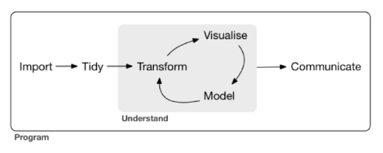

Für den Entwurf von QS-Strategien erscheint es sinnvoll das oben gezeigte Diagramm zu erweitern. Bei dieser Erweiterung werden die bestimmenden Disziplinen der einzelnen Bestandteile eingezeichtnet. Im wesentlichen besteht ein Data-Science-Projekt aus

- **Software**
- **Statistik** und
- **Kommunikation**

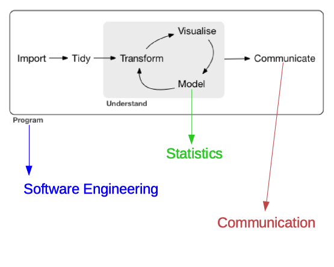

Somit setzt sich die QS in Data-Science-Projekten aus der QS der einzelnen Bestandteile zusammen.

## Kommunikation

Bei der Kommunikation ist es nicht einfach einen formellen Qualitätsbegriff zu definieren. Vereinfacht können wir hier einfach festhalten, dass Kommunikation dann gut ist, wenn die zu übermittelnde Nachricht beim Empfänger oder der Empfängerin ankommt und verstanden wird.

## Statistik

Da Statistik als eine Unterdisziplin der Mathematik verstanden werden kann, lassen sich Qualitätskriterien über mathematische Grössen definieren. Die Hauptaufgabe der Statistik in einem Data-Science-Prozess ist es ein Modell zu erstellen, das Modell an die beobachteten Daten anzupassen und dann die Modellqualität zu ermitteln.

Auf einer abstrakten Ebene, das heisst bevor wir Daten gesammelt oder beobachtet haben besteht ein statistisches Modell aus den folgenden Komponenten.

- Zielgrösse
- erklärende Variablen und
- eine mathematische Funktion.

Die Beziehung zwischen den Bestandteilen sind im folgenden Diagramm dargestellt. Dabei ist die mathematische Funktion im Zentrum. Sie nimmt die erklärenden Variablen als Input auf und verknüft diese mit gewissen Funktionsparametern. Als Resultat dieser Verknüpfungsoperation erhalten wir die Zielgrösse.

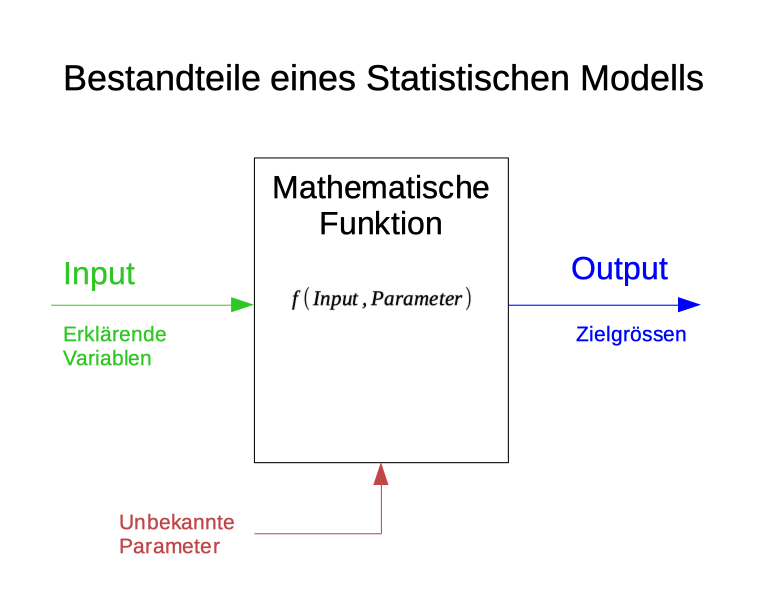

Wie schon erwähnt, ist die oben gezeigte Darstellung für die Situation gültig, in der wir noch keine Daten beobachtet haben. Sobald wir einen Datensatz haben, anhand dessen wir ein konkretes Modell anpassen können, müssen wir das Diagramm wie folgt erweitern.

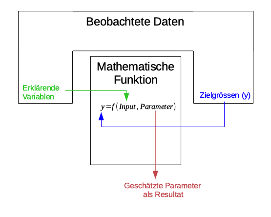

Im Innenleben der mathematischen Funktion werden die erklärenden Variablen mit unbekannten Parametern so verküpft dass als Ergebniss die Zielvariablen möglichst genau angenähert werden. Die Hauptaufgabe der Statistik besteht in der Schätzung der unbekannten Parametern, so dass die mathematische Beziehung zwischen den erklärenden Variablen und den Zielgrössen möglichst gut ist.

## Software Engineering

Über Qualitätssicherung im Gebiet des Software-Engineerings wurde viel geschrieben. Ich finde die zwölf Regeln von Joel Spolski sehr wertvoll und einen guten Ausgangspunkt. Die Regeln sind in [Joels Blog](https://www.joelonsoftware.com/2000/08/09/the-joel-test-12-steps-to-better-code/) aufgelistet und erklärt.

*Latest Changes: 2020-01-15 07:58:13 (pvr)*